# Capstone Project (Bellabeat)

Steven Kurniawan

9/4/2021

## First Data Analysis Project

How can a Wellness Technology Company Play it Smart?

This capstone project will focus on a case study that deals with a company called Bellabeat. This will be my first project that I will examine to gain insight of the company as well as fulfill Google Data Anayltics Professional Certificate Program curriculum.

In this project I will use R studio to organize, clean, process, aggregate, and visualize different data sets that will comprise a further understanding of the company’s mission.

## Background of Company

Bellabeat is a technology manufactured company that focuses on wellness and health products directed towards the women demographics. It’s a small comapny that has the potential to play a larger role in the global smart device market. Through the process of data analysis and understanding the data that their products and services output, the company believes they can expand their growth.

## Questions to Ask

1. What are some trends in smart device usage?
2. How could these trends apply to Bellabeat customers?
3. How could these trends help influence Bellabeat marketing strategy

## Key Tasks

1. Identify the business task- Focus on one of Bellabeat products, and analyze smart device data to gain insight into how consumers are using smart devices. Need high level recommendations for how these trends can inform Bellabeat’s marketing strategy. Identify potential opportunities for growth and recommendations for the Bellabeat marketing strategy improvement based on trends in smart device usage.
2. Consider key stakeholders Deliverable Urška Sršen: Bellabeat’s co-founder and Chief Creative Officer Sando Mur: Mathematician and Bellabeat’s co-founder; key member of the Bellabeat executive team. Bellabeat marketing analytics team: A team of data analysts responsible for collecting, analyzing, and reporting data that helps guide Bellabeat’s marketing strategy. You joined this team six months ago and have been busy learning about Bellabeat’’s mission and business goals — as well as how you, as a junior data analyst, can help Bellabeat achieve them.

## Installing neccesary packages, as well as loading the libraries

```r
## Since I have already installed the neccesary packages, I will just put them as comment references to show my steps.

# install.packages(tidyverse)
# install.packages(lubridate)
# install.packages(dplyr)
# install.packages(ggplot2)
# install.packages(tidyr)
# install.packages(readr)
# install.packages(stringr)

## After installing the packages, I will laod the libraries.
library(tidyverse)
library(lubridate)
library(dplyr)
library(ggplot2)
library(tidyr)
library(readr)
library(stringr)
```

## Importing the Data

```r
dailyActivity_merged <- read_csv("dailyActivity_merged.csv")
dailyCalories_merged <- read_csv("dailyCalories_merged.csv")
hourlyIntensities_merged <- read_csv("hourlyIntensities_merged.csv")
sleepDay_merged <- read_csv("sleepDay_merged.csv")
weightLogInfo_merged <- read_csv("weightLogInfo_merged.csv")
## I will then assign different names to the files to make it easier to follow.
Activity <- dailyActivity_merged
Calories <- dailyCalories_merged
Intensities <- hourlyIntensities_merged
Sleep <- sleepDay_merged
Weight <- weightLogInfo_merged
```

## Viewing Data

Now, we need to view the data to make sure it was correctly imported. Checking the data will also will also allow me to see if there are any problems with the data, whether it be null values, errors,formatting issues, etc.

```r
summary(Calories)
```

```
##        Id            ActivityDay           Calories
##  Min.   :1.504e+09   Length:940         Min.   :   0
##  1st Qu.:2.320e+09   Class :character   1st Qu.:1828
##  Median :4.445e+09   Mode  :character   Median :2134
##  Mean   :4.855e+09                      Mean   :2304
##  3rd Qu.:6.962e+09                      3rd Qu.:2793
##  Max.   :8.878e+09                      Max.   :4900
```

```r
glimpse(Intensities)
```

```
## Rows: 22,099
## Columns: 4
## $ Id               <dbl> 1503960366, 1503960366, 1503960366, 1503960366, 15039…
## $ ActivityHour     <chr> "4/12/2016 12:00:00 AM", "4/12/2016 1:00:00 AM", "4/1…
## $ TotalIntensity   <dbl> 20, 8, 7, 0, 0, 0, 0, 0, 13, 30, 29, 12, 11, 6, 36, 5…
## $ AverageIntensity <dbl> 0.333333, 0.133333, 0.116667, 0.000000, 0.000000, 0.0…
```

```r
head(Sleep)
```

```
## # A tibble: 6 × 5
##           Id SleepDay              TotalSleepRecor… TotalMinutesAsl… TotalTimeInBed
##        <dbl> <chr>                            <dbl>            <dbl>          <dbl>
## 1 1503960366 4/12/2016 12:00:00 AM                1              327            346
## 2 1503960366 4/13/2016 12:00:00 AM                2              384            407
## 3 1503960366 4/15/2016 12:00:00 AM                1              412            442
## 4 1503960366 4/16/2016 12:00:00 AM                2              340            367
## 5 1503960366 4/17/2016 12:00:00 AM                1              700            712
## 6 1503960366 4/19/2016 12:00:00 AM                1              304            320
```

```r
glimpse(Weight)
```

```
## Rows: 67
## Columns: 8
## $ Id             <dbl> 1503960366, 1503960366, 1927972279, 2873212765, 2873212…
## $ Date           <chr> "5/2/2016 11:59:59 PM", "5/3/2016 11:59:59 PM", "4/13/2…
## $ WeightKg       <dbl> 52.6, 52.6, 133.5, 56.7, 57.3, 72.4, 72.3, 69.7, 70.3, …
## $ WeightPounds   <dbl> 115.9631, 115.9631, 294.3171, 125.0021, 126.3249, 159.6…
## $ Fat            <dbl> 22, NA, NA, NA, NA, 25, NA, NA, NA, NA, NA, NA, NA, NA,…
## $ BMI            <dbl> 22.65, 22.65, 47.54, 21.45, 21.69, 27.45, 27.38, 27.25,…
## $ IsManualReport <lgl> TRUE, TRUE, FALSE, TRUE, TRUE, TRUE, TRUE, TRUE, TRUE, …
## $ LogId          <dbl> 1.462234e+12, 1.462320e+12, 1.460510e+12, 1.461283e+12,…
```

## Formatting Issues

There was some formatting issues when it came to time and date. The date/time needs to be converted and split into date and time.

```r
# Intensities
Intensities$ActivityHour=as.POSIXct(Intensities$ActivityHour, format="%m/%d/%Y %I:%M:%S %p", tz=Sys.timezone())
Intensities$time <- format(Intensities$ActivityHour, format = "%H:%M:%S")
Intensities$date <- format(Intensities$ActivityHour, format = "%m/%d/%y")
# Activity
Activity$ActivityDate=as.POSIXct(Activity$ActivityDate, format="%m/%d/%Y", tz=Sys.timezone())
Activity$date <- format(Activity$ActivityDate, format = "%m/%d/%y")
# Sleep
Sleep$SleepDay=as.POSIXct(Sleep$SleepDay, format="%m/%d/%Y %I:%M:%S %p", tz=Sys.timezone())
Sleep$date <- format(Sleep$SleepDay, format = "%m/%d/%y")
```

## Exploring the Datset and Summarizing

```r
## n_distinct function will specify and pull out specific and particular observations from the variables we have.
n_distinct(Activity$Id)
```

```
## [1] 33
```

```r
n_distinct(Calories$Id)
```

```
## [1] 33
```

```r
n_distinct(Intensities$Id)
```

```
## [1] 33
```

```r
n_distinct(Sleep$Id)
```

```
## [1] 24
```

```r
n_distinct(Weight$Id)
```

```
## [1] 8
```

Summary Statistics of Data set

```r
# Activity
Activity %>%
  select(TotalSteps,TotalDistance,SedentaryMinutes, Calories) %>%
  summary()
```

```
##    TotalSteps    TotalDistance    SedentaryMinutes    Calories
##  Min.   :    0   Min.   : 0.000   Min.   :   0.0   Min.   :   0
##  1st Qu.: 3790   1st Qu.: 2.620   1st Qu.: 729.8   1st Qu.:1828
##  Median : 7406   Median : 5.245   Median :1057.5   Median :2134
##  Mean   : 7638   Mean   : 5.490   Mean   : 991.2   Mean   :2304
##  3rd Qu.:10727   3rd Qu.: 7.713   3rd Qu.:1229.5   3rd Qu.:2793
##  Max.   :36019   Max.   :28.030   Max.   :1440.0   Max.   :4900
```

```r
# Active minutes per categories
Activity %>%
  select(VeryActiveMinutes, FairlyActiveMinutes, LightlyActiveMinutes) %>%
  summary()
```

```
##  VeryActiveMinutes FairlyActiveMinutes LightlyActiveMinutes
##  Min.   :  0.00    Min.   :  0.00      Min.   :  0.0
##  1st Qu.:  0.00    1st Qu.:  0.00      1st Qu.:127.0
##  Median :  4.00    Median :  6.00      Median :199.0
##  Mean   : 21.16    Mean   : 13.56      Mean   :192.8
##  3rd Qu.: 32.00    3rd Qu.: 19.00      3rd Qu.:264.0
##  Max.   :210.00    Max.   :143.00      Max.   :518.0
```

```r
# Calories
Calories %>%
  select(Calories) %>%
  summary()
```

```
##     Calories
##  Min.   :   0
##  1st Qu.:1828
##  Median :2134
##  Mean   :2304
##  3rd Qu.:2793
##  Max.   :4900
```

```r
# Sleep
Sleep %>%
  select(TotalSleepRecords, TotalMinutesAsleep, TotalTimeInBed) %>%
  summary()
```

```
##  TotalSleepRecords TotalMinutesAsleep TotalTimeInBed
##  Min.   :1.000     Min.   : 58.0      Min.   : 61.0
##  1st Qu.:1.000     1st Qu.:361.0      1st Qu.:403.0
##  Median :1.000     Median :433.0      Median :463.0
##  Mean   :1.119     Mean   :419.5      Mean   :458.6
##  3rd Qu.:1.000     3rd Qu.:490.0      3rd Qu.:526.0
##  Max.   :3.000     Max.   :796.0      Max.   :961.0
```

```r
# Weight
Weight %>%
  select(WeightKg, BMI) %>%
  summary()
```

```
##     WeightKg           BMI
##  Min.   : 52.60   Min.   :21.45
##  1st Qu.: 61.40   1st Qu.:23.96
##  Median : 62.50   Median :24.39
##  Mean   : 72.04   Mean   :25.19
##  3rd Qu.: 85.05   3rd Qu.:25.56
##  Max.   :133.50   Max.   :47.54
```

## Merging Data

We now can merge the data because the variables we need are in complimentary to each other. This is an important step before visualizing the data because we have previously converted the data from date/time to data and time. Merging the data consists of the activity and sleep dataset on columns ID and date.

```r
merged_data <- merge(Sleep, Activity, by= c('Id', 'date'))
head(merged_data)
```

```
##           Id     date   SleepDay TotalSleepRecords TotalMinutesAsleep
## 1 1503960366 04/12/16 2016-04-12                 1                327
## 2 1503960366 04/13/16 2016-04-13                 2                384
## 3 1503960366 04/15/16 2016-04-15                 1                412
## 4 1503960366 04/16/16 2016-04-16                 2                340
## 5 1503960366 04/17/16 2016-04-17                 1                700
## 6 1503960366 04/19/16 2016-04-19                 1                304
##   TotalTimeInBed ActivityDate TotalSteps TotalDistance TrackerDistance
## 1            346   2016-04-12      13162          8.50            8.50
## 2            407   2016-04-13      10735          6.97            6.97
## 3            442   2016-04-15       9762          6.28            6.28
## 4            367   2016-04-16      12669          8.16            8.16
## 5            712   2016-04-17       9705          6.48            6.48
## 6            320   2016-04-19      15506          9.88            9.88
##   LoggedActivitiesDistance VeryActiveDistance ModeratelyActiveDistance
```

[output cut: 20 more lines]

## Visualization

Now we want to provide some context to the data, and provide visualizations to datsets to provide a visual narrative. To create some visualizations that make sense to the data, I will make various graphs thats will produce a scatterplot, and a bar graph to indicate the relationships between the various variables.

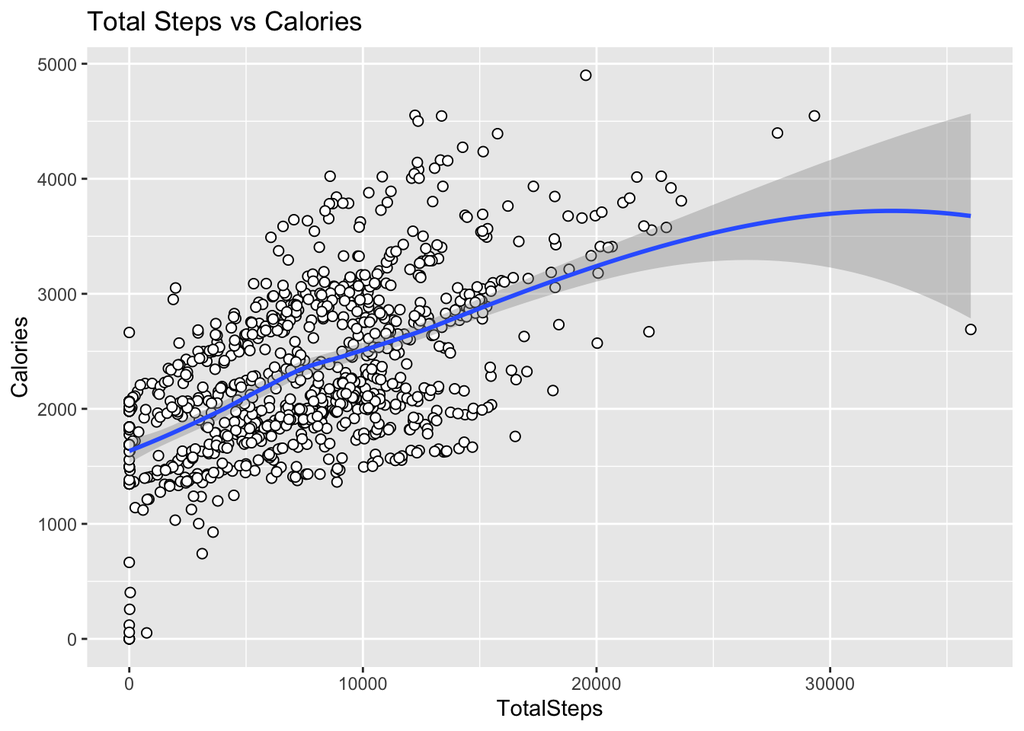

```r
ggplot(data=Activity, aes(x=TotalSteps, y=Calories)) +
  geom_point(size=2, shape=21, fill="White")+
  geom_smooth()+
  labs(title= "Total Steps vs Calories")
```

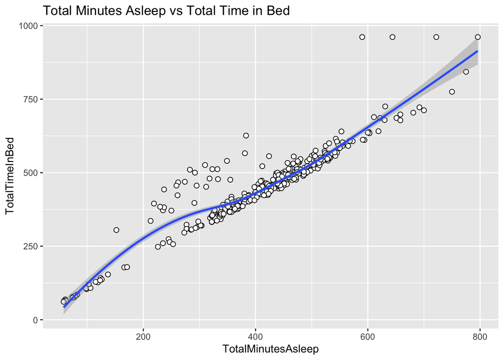

```r
ggplot(data=Sleep, aes(x=TotalMinutesAsleep, y=TotalTimeInBed))+
  geom_point(size=2, shape=21, fill="White")+
  geom_smooth()+
  labs(title= "Total Minutes Asleep vs Total Time in Bed")
```

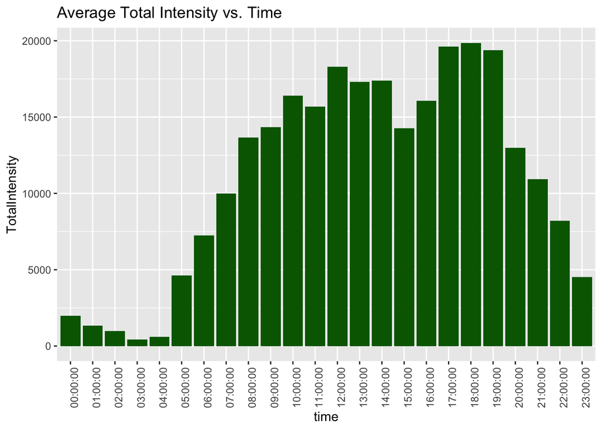

```r
int_new<- Intensities %>%
  group_by(time) %>%
  drop_na() %>%
  summarise(mean_total_int = mean(TotalIntensity))

ggplot(data=Intensities, aes(x=time, y=TotalIntensity))+
  geom_histogram(stat = "identity", fill='darkgreen') +
  theme(axis.text.x = element_text(angle = 90)) +
  labs(title="Average Total Intensity vs. Time")
```

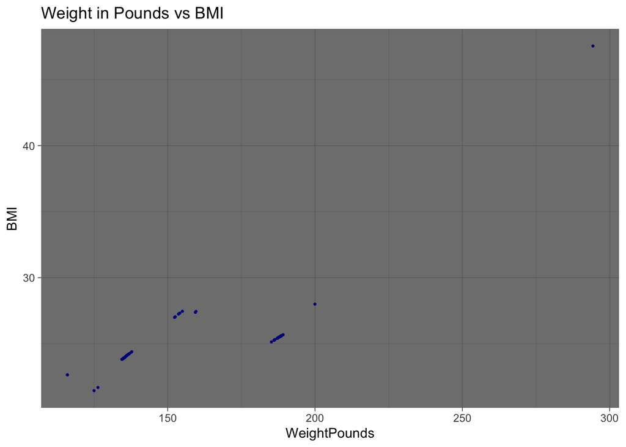

```r
ggplot(data=Weight, aes(x=WeightPounds, y=BMI))+
  geom_point(color= "darkblue", size=0.5)+
  labs(title= "Weight in Pounds vs BMI")+
  theme_dark()
```

After making different charts and graphs to give some context for these datasets, we can give some insight to Bellabeat and their marketing team. In the first scatterplot, we can see that there is a postive correlation between Total Steps vs Calories. This makes sense because the more tatal steps means the more active you are and the more calories you will burn.

In the second scatterplot, we can see the relationship between the Total Time in Asleep vs Total Time Asleep shows a positive and linear corellation. To make a suggestion to the users, we can advise them to turn stop using all of their electronic devices at a certain time and keeping a stop limit when it is time for bedtime, to improve thier quality of sleep.

In the third bar graph, we can see the relationship between Time vs Total Intensity. There is a high level and peak activity at 5:00PM - 7:00PM and drastically lowers after 8:00PM. This also makes sense because the average workday ends at about 4-5PM so most people might be more active and workout, go to the gym, participate in any activity after their work hours. We can implement a system in the app when their is minimal activity to alert them of that status. This will reinforce and create a reminder for the users to be active. There should also be a reward and punish system, lets say that if they are lower than their lowest average then they should be warned, and if they pass their highest levels of activity they should receive an in app reward.

## Conclusion/ Final Thoghts

After undergoing our research, analyzing the context of the data, providing a visual narrative and context, we can finally give some suggestions to the Bellabeat marketing strategy team.

Target audience

Since Bellabeat’s approach and products are directed towards the female demographic, we can transition our focus towards that and implement proven strategies that have historically proven to work. A recent study by Bustle found that 81% of female millennials said social media was the best way for brands to reach them. Of those, around half said Facebook was the platform of choice, while the other half chose Instagram. Pinterest is also a strong platform of choice for marketing to a female demographic, with 78% of active Pinners welcoming branded content and messaging. In the Ernst and Young Groundbreakers, E&Y that women reinvest 90% of their income into their families and communities, compared to men, who reinvest only 30-40%. On top of that, 81% of millennials say they want companies to be good corporate citizens. Combined, both statistics present a compelling argument for brands to consider partnering with or championing a cause to create appealing marketing to a female demographic. Women dominate the influencer marketing space and accounted for 83.9% of all ad posts in 2017. In most cases, female influencers tend to attract an audience of other women, which makes them ideal channels for brands to use in marketing to a female demographic. Often, micro-influencers and even everyday brand customers can be used to build awareness of a brand, product, or services. Influencer marketing isn’t effective because of the size of an audience. It’s effective because influencer marketing by its nature fosters more trust and credibility than traditional advertising. In fact, 76% of individuals surveyed say that they’re more likely to trust content shared by “normal” people than content shared by brands. Hire women from different backgrounds, and at different levels, across your brand’s company.Hiring women opens your brand to the knowledge, background, and human layer that is essential to successful campaigns that you wouldn’t get from single gender teams.

Ideas for the Bellabeat app

From our Analysis we can see that collecting data on activty, sleep, stress, weight, among other things has kept the company to perform and maintain their framework to empower women on their health. In our findings through our analysis we can see that the total average steps per day is 7638, which is a little below the findings of the CDC research. According to CDC, taking 8000 steps per day was associated with 51% lower risk for all cause mortality or from all causes. Taking 12,000 steps per day was associated with 65% lower risk compared with taking 4000 steps. So we can encourage our users to take at least 8000 steps per day. If users want to track their sleep pattern they should take mindful steps to produce a healthier lifestyle. Setting a bed time system with the app will allow a more productive sleeping habit. If users want to improve or maintain their weight quality, they should include different informational forums and videos to better food choices, dietary information, and all around platform to better food consumption, training sessions, and calorie counting application. In terms of activity, the app should allow a system of activity tracking where users steps are counted and energy levels are also tracked. This will provide the users a notification if they are not where they should be in terms of activity levels.

Our main focus is to Bellebeat’s customers by providing them efficiency, affordability(price point), user protection and privacy, to ensure effectiveness and satisfaction of products, and accessibility to consumers whether it be product consumption or physical/ digital expenditures. If these factors are taken into consideration then the company can make some headway and dominate the market.